# Apunte 10 — Regresión logística aplicada

Analítica de Personas · Semestre otoño 2026 · Semana 3 · Caso InnovaCo

## 1. La intuición: ¿por qué regresión logística?

Queremos predecir si un empleado se va a ir (Sí/No). La variable dependiente es **binaria**. La regresión lineal no funciona aquí porque puede predecir probabilidades menores que 0 o mayores que 1, lo cual no tiene sentido.

La regresión logística resuelve esto con la **función logística (sigmoid)**, que transforma cualquier valor real en una probabilidad acotada entre 0 y 1:

P(irse = 1) = 1 / (1 + e<sup>−(β₀ + β₁X₁ + β₂X₂ + ...)</sup>)

La curva tiene forma de "S": cuando el predictor es muy bajo, la probabilidad está cerca de 0; cuando es muy alto, cerca de 1; y la transición es gradual, no abrupta.

## 2. Paso a paso: construir el modelo en R

### 2.1 Preparar los datos

```
library(tidyverse)
library(broom)

innovaco <- read_csv("innovaco_empleados.csv")

# Crear variable binaria
innovaco <- innovaco |>
  mutate(rotacion_bin = if_else(rotacion == "Sí", 1, 0))

# Verificar la tasa base
mean(innovaco$rotacion_bin)
# ~0.27 → el 27% se va. Este es nuestro baseline.
```

### 2.2 Modelo nulo (referencia)

```
# Sin predictores: solo la tasa base
mod_nulo <- glm(rotacion_bin ~ 1, data = innovaco, family = binomial)

# El intercepto en probabilidad:
plogis(coef(mod_nulo))  # ≈ 0.27 (la tasa de rotación)
```

### 2.3 Modelo simple → múltiple → extendido

```
# Modelo 1: solo satisfacción
mod_1 <- glm(rotacion_bin ~ satisfaccion_laboral,
             data = innovaco, family = binomial)

# Modelo 2: satisfacción + antigüedad + edad
mod_3 <- glm(rotacion_bin ~ satisfaccion_laboral + antiguedad_anios + edad,
             data = innovaco, family = binomial)

# Modelo 3: agregar departamento e ingreso
mod_ext <- glm(rotacion_bin ~ satisfaccion_laboral + antiguedad_anios +
                               edad + departamento + ingreso_mensual,
               data = innovaco, family = binomial)
```

### 2.4 Comparar con AIC

```
bind_rows(
  glance(mod_nulo) |> mutate(modelo = "0. Nulo"),
  glance(mod_1)    |> mutate(modelo = "1. Satisfacción"),
  glance(mod_3)    |> mutate(modelo = "2. Sat+Antig+Edad"),
  glance(mod_ext)  |> mutate(modelo = "3. Extendido")
) |>
  select(modelo, AIC, BIC, deviance) |>
  arrange(AIC)
```

## 3. Interpretar odds ratios

```
# Tabla de odds ratios del mejor modelo
tidy(mod_ext, exponentiate = TRUE, conf.int = TRUE) |>
  filter(term != "(Intercept)") |>
  mutate(
    interpretacion = case_when(
      estimate < 1 ~ paste0("Reduce chances en ",
                             round((1 - estimate) * 100), "%"),
      estimate > 1 ~ paste0("Aumenta chances en ",
                             round((estimate - 1) * 100), "%"),
      TRUE ~ "Sin efecto"
    )
  )
```

## 4. Visualizaciones del modelo

### 4.1 La curva S: probabilidad predicha vs. un predictor

Esta visualización muestra la curva logística: cómo cambia la probabilidad de rotación a medida que varía un predictor, manteniendo los demás constantes.

```
# Crear datos para la curva (variando satisfacción, fijando el resto en la mediana)
datos_curva <- tibble(
  satisfaccion_laboral = seq(1, 5, by = 0.1),
  antiguedad_anios     = median(innovaco$antiguedad_anios),
  edad                 = median(innovaco$edad),
  departamento         = "Desarrollo",  # categoría de referencia
  ingreso_mensual      = median(innovaco$ingreso_mensual)
)

# Predecir probabilidades
datos_curva <- datos_curva |>
  mutate(prob_predicha = predict(mod_ext, newdata = datos_curva,
                                  type = "response"))

# Gráfico de la curva S
ggplot(datos_curva, aes(x = satisfaccion_laboral, y = prob_predicha)) +
  geom_line(color = "#B85042", linewidth = 1.2) +
  geom_hline(yintercept = mean(innovaco$rotacion_bin),
             linetype = "dashed", color = "gray50") +
  annotate("text", x = 4.5, y = mean(innovaco$rotacion_bin) + 0.03,
           label = "Tasa base (27%)", color = "gray50", size = 3) +
  scale_y_continuous(labels = scales::percent, limits = c(0, 1)) +
  labs(
    title = "Probabilidad de rotación según satisfacción laboral",
    subtitle = "Manteniendo edad, antigüedad e ingreso en la mediana",
    x = "Satisfacción laboral (1-5)",
    y = "Probabilidad predicha de irse"
  ) +
  theme_minimal()
```

### 4.2 Probabilidades predichas vs. datos reales (jitter plot)

Este gráfico superpone las probabilidades predichas sobre los datos reales (0/1), mostrando cuán bien separa el modelo a los dos grupos.

```
# Agregar predicciones al dataset
innovaco <- innovaco |>
  mutate(prob_predicha = predict(mod_ext, type = "response"))

# Jitter plot: distribución de probabilidades por grupo real
ggplot(innovaco, aes(x = rotacion, y = prob_predicha, color = rotacion)) +
  geom_jitter(alpha = 0.3, width = 0.2, height = 0) +
  geom_boxplot(alpha = 0.5, outlier.shape = NA, width = 0.4) +
  geom_hline(yintercept = 0.5, linetype = "dashed", color = "gray40") +
  annotate("text", x = 2.4, y = 0.52,
           label = "Umbral = 0.5", color = "gray40", size = 3) +
  scale_color_manual(values = c("No" = "#0D9488", "Sí" = "#B85042")) +
  scale_y_continuous(labels = scales::percent) +
  labs(
    title = "Distribución de probabilidades predichas por grupo real",
    subtitle = "Un buen modelo separa claramente los dos grupos",
    x = "Rotación real",
    y = "Probabilidad predicha",
    color = "Rotación real"
  ) +
  theme_minimal() +
  theme(legend.position = "none")
```

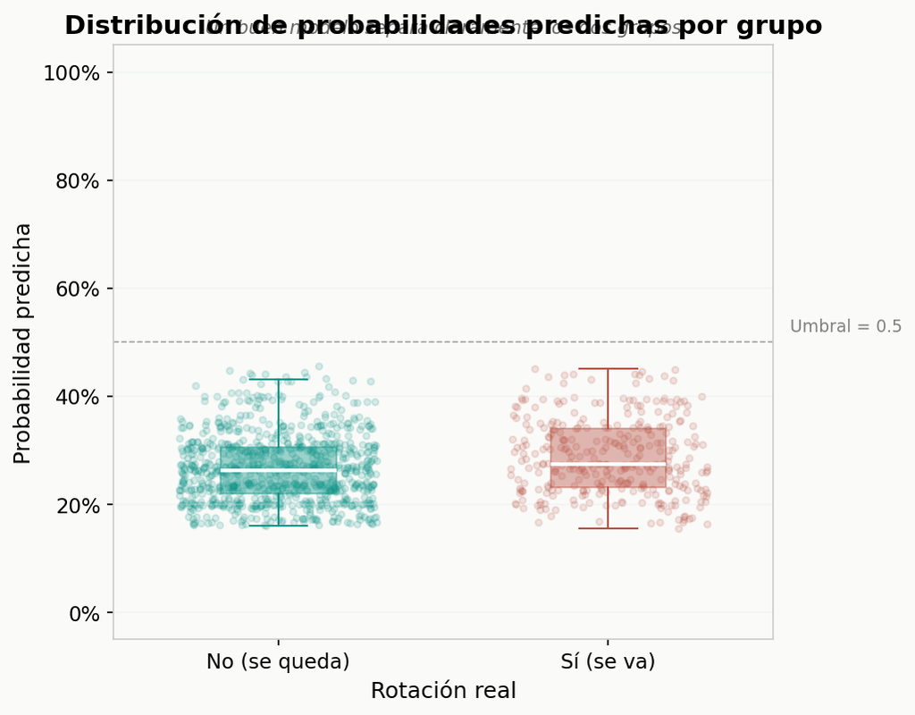

Figura 4: Distribución de probabilidades predichas por grupo real

**¿Cómo leer este gráfico?** Si el modelo funciona bien, los puntos "No" (teal) estarán concentrados abajo (probabilidad baja de irse) y los "Sí" (terracotta) estarán concentrados arriba (probabilidad alta de irse). Si los dos grupos se superponen mucho, el modelo no discrimina bien.

### 4.3 Histograma de probabilidades predichas por grupo

```
# Histograma facetado
ggplot(innovaco, aes(x = prob_predicha, fill = rotacion)) +
  geom_histogram(bins = 30, alpha = 0.7, position = "identity") +
  geom_vline(xintercept = 0.5, linetype = "dashed") +
  scale_fill_manual(values = c("No" = "#0D9488", "Sí" = "#B85042")) +
  facet_wrap(~ rotacion, ncol = 1) +
  scale_x_continuous(labels = scales::percent) +
  labs(
    title = "Distribución de probabilidades predichas",
    subtitle = "¿El modelo logra separar los que se van de los que se quedan?",
    x = "Probabilidad predicha de irse",
    y = "Cantidad de empleados"
  ) +
  theme_minimal() +
  theme(legend.position = "none")
```

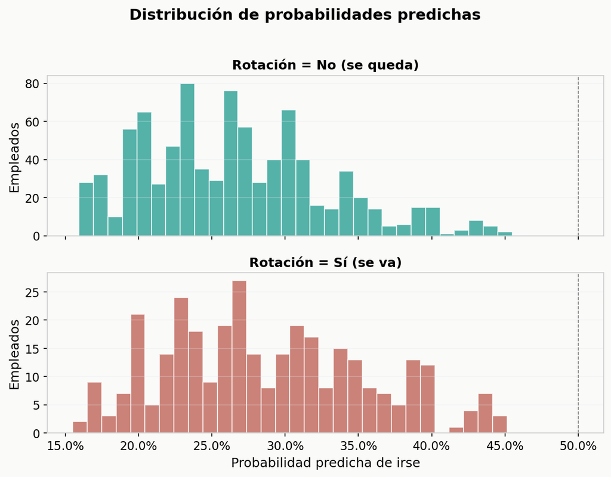

Figura 5: Histograma de probabilidades predichas facetado por grupo

### 4.4 Forest plot de odds ratios

```
# Preparar datos
or_datos <- tidy(mod_ext, exponentiate = TRUE, conf.int = TRUE) |>
  filter(term != "(Intercept)") |>
  mutate(
    variable = case_when(
      term == "satisfaccion_laboral" ~ "Satisfacción laboral",
      term == "antiguedad_anios"     ~ "Antigüedad (años)",
      term == "edad"                 ~ "Edad",
      term == "ingreso_mensual"      ~ "Ingreso mensual",
      str_detect(term, "departamento") ~
        str_replace(term, "departamento", "Depto: "),
      TRUE ~ term
    ),
    significativo = p.value < 0.05
  )

# Forest plot
ggplot(or_datos, aes(x = estimate, y = reorder(variable, estimate))) +
  geom_vline(xintercept = 1, linetype = "dashed", color = "gray50") +
  geom_point(aes(color = significativo), size = 3) +
  geom_errorbarh(aes(xmin = conf.low, xmax = conf.high,
                      color = significativo), height = 0.2) +
  scale_color_manual(
    values = c("TRUE" = "#B85042", "FALSE" = "gray60"),
    labels = c("TRUE" = "p < .05", "FALSE" = "No significativo")
  ) +
  labs(
    title = "Factores asociados a la rotación en InnovaCo",
    subtitle = "OR > 1 = mayor riesgo | OR < 1 = factor protector",
    x = "Odds Ratio", y = NULL, color = "Significancia"
  ) +
  theme_minimal() +
  theme(legend.position = "bottom")
```

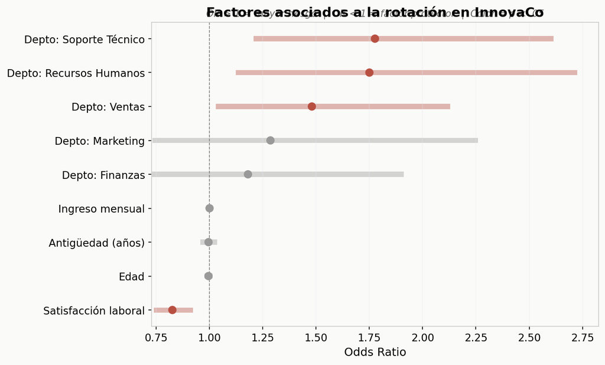

Figura 6: Forest plot de odds ratios con IC 95%

### 4.5 Curva S con datos reales superpuestos

```
# Curva logística con datos reales (puntos jitter)
# geom_smooth construye el IC en la escala logit y lo transforma
# de vuelta a probabilidades automáticamente
ggplot(innovaco, aes(x = satisfaccion_laboral, y = rotacion_bin)) +
  geom_jitter(alpha = 0.15, height = 0.05, width = 0.1,
              color = "gray50") +
  geom_smooth(method = "glm", method.args = list(family = "binomial"),
              color = "#B85042", fill = "#B85042", alpha = 0.2) +
  scale_y_continuous(labels = scales::percent,
                     breaks = c(0, 0.25, 0.5, 0.75, 1)) +
  labs(
    title = "La curva logística: satisfacción laboral y rotación",
    subtitle = "Cada punto es un empleado (0 = se queda, 1 = se fue)",
    x = "Satisfacción laboral",
    y = "Probabilidad de irse"
  ) +
  theme_minimal()
```

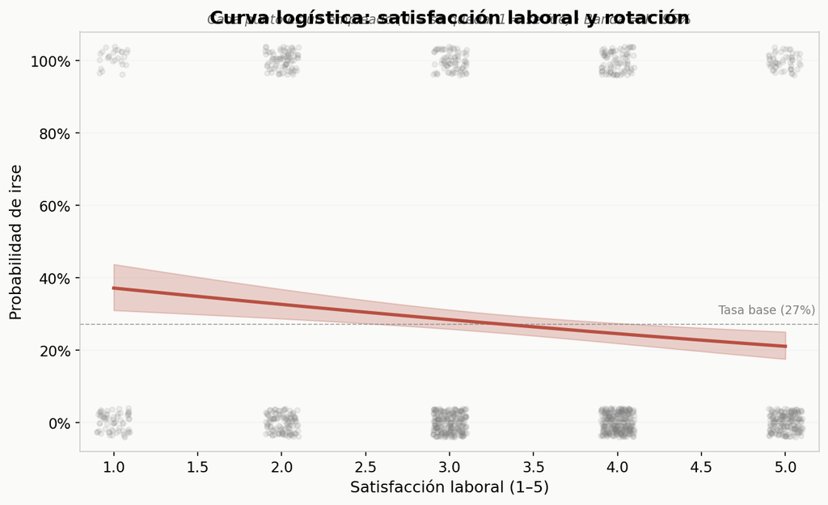

Figura 1: Curva logística con IC 95% — un solo predictor (satisfacción laboral)

**geom_smooth() con method = "glm" y family = "binomial"** Esta es la forma más rápida de visualizar una regresión logística sobre un solo predictor. `geom_smooth()` ajusta el modelo y dibuja la curva S con banda de confianza automáticamente. Internamente, ggplot2 construye el intervalo de confianza en la escala del enlace (logit) y luego lo transforma de vuelta a la escala de probabilidades, lo cual es el procedimiento correcto.

## 4B. Gráficos predictivos con intervalo de confianza (método manual)

Cuando el modelo tiene **múltiples predictores**, `geom_smooth()` ya no sirve directamente (solo trabaja con un predictor en el eje X). En ese caso, construimos las predicciones y los intervalos de confianza manualmente usando `augment()` o `predict()`.

### La lógica clave

Para construir un intervalo de confianza correcto en regresión logística, hay que:

1. Obtener las predicciones y errores estándar **en la escala del enlace (logit)**, no en probabilidades.
2. Construir el IC en esa escala: predicción ± 1.96 × SE.
3. **Transformar de vuelta a probabilidades** usando `plogis()` (la función inversa del logit).

¿Por qué no construir el IC directamente en probabilidades? Porque el IC en la escala logit es simétrico, pero al transformarlo a probabilidades queda correctamente asimétrico y acotado entre 0 y 1.

### 4B.1 Método con augment() + plogis()

```
library(broom)

# Paso 1: obtener predicciones en la escala del enlace (logit)
# type.predict = "link" devuelve log-odds + SE
pred_datos <- augment(mod_ext, type.predict = "link", se_fit = TRUE)

# Paso 2: construir IC en la escala logit, luego transformar a probabilidades
pred_datos <- pred_datos |>
  mutate(
    prob_predicha = plogis(.fitted),                        # probabilidad
    prob_lower    = plogis(.fitted - 1.96 * .se.fit),      # IC inferior
    prob_upper    = plogis(.fitted + 1.96 * .se.fit)       # IC superior
  )

# Verificar: las probabilidades están entre 0 y 1 (siempre)
pred_datos |>
  summarise(
    min_prob  = min(prob_predicha),
    max_prob  = max(prob_predicha),
    min_lower = min(prob_lower),
    max_upper = max(prob_upper)
  )
```

### 4B.2 Gráfico: probabilidad predicha con IC, variando un predictor

```
# Crear grilla de valores: variar satisfacción, fijar el resto en la mediana
grilla <- tibble(
  satisfaccion_laboral = seq(1, 5, by = 0.1),
  antiguedad_anios     = median(innovaco$antiguedad_anios),
  edad                 = median(innovaco$edad),
  departamento         = "Desarrollo",
  ingreso_mensual      = median(innovaco$ingreso_mensual)
)

# Predecir en la escala logit con SE
pred_grilla <- predict(mod_ext, newdata = grilla,
                       type = "link", se.fit = TRUE)

# Agregar al tibble y transformar a probabilidades
grilla <- grilla |>
  mutate(
    logit_fit = pred_grilla$fit,
    logit_se  = pred_grilla$se.fit,
    prob      = plogis(logit_fit),
    prob_low  = plogis(logit_fit - 1.96 * logit_se),
    prob_high = plogis(logit_fit + 1.96 * logit_se)
  )

# Gráfico con banda de confianza
ggplot(grilla, aes(x = satisfaccion_laboral)) +
  geom_ribbon(aes(ymin = prob_low, ymax = prob_high),
              fill = "#B85042", alpha = 0.2) +
  geom_line(aes(y = prob), color = "#B85042", linewidth = 1.2) +
  geom_jitter(data = innovaco,
              aes(x = satisfaccion_laboral, y = rotacion_bin),
              alpha = 0.1, height = 0.03, width = 0.1,
              color = "gray50") +
  geom_hline(yintercept = mean(innovaco$rotacion_bin),
             linetype = "dashed", color = "gray60") +
  scale_y_continuous(labels = scales::percent, limits = c(0, 1)) +
  labs(
    title = "Probabilidad predicha de rotación según satisfacción",
    subtitle = "Línea = predicción | Banda = IC 95% | Línea punteada = tasa base",
    x = "Satisfacción laboral (1-5)",
    y = "P(irse)",
    caption = "Variables fijadas en la mediana. Modelo: regresión logística multivariada."
  ) +
  theme_minimal()
```

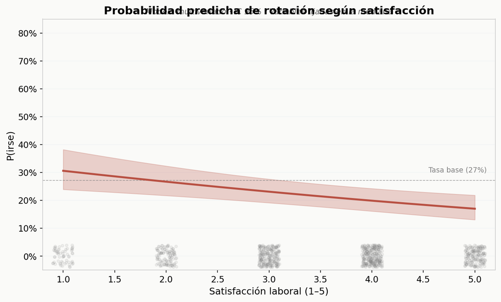

Figura 2: Predicción multivariada con IC 95% — satisfacción variando, resto en la mediana

### 4B.3 Gráfico por departamento (facetado)

```
# Grilla con todos los departamentos
deptos <- distinct(innovaco, departamento)

grilla_depto <- expand_grid(
  satisfaccion_laboral = seq(1, 5, by = 0.1),
  departamento         = deptos$departamento,
  antiguedad_anios     = median(innovaco$antiguedad_anios),
  edad                 = median(innovaco$edad),
  ingreso_mensual      = median(innovaco$ingreso_mensual)
)

# Predecir con IC
pred_depto <- predict(mod_ext, newdata = grilla_depto,
                      type = "link", se.fit = TRUE)

grilla_depto <- grilla_depto |>
  mutate(
    prob     = plogis(pred_depto$fit),
    prob_low = plogis(pred_depto$fit - 1.96 * pred_depto$se.fit),
    prob_high = plogis(pred_depto$fit + 1.96 * pred_depto$se.fit)
  )

# Facetado por departamento
ggplot(grilla_depto, aes(x = satisfaccion_laboral)) +
  geom_ribbon(aes(ymin = prob_low, ymax = prob_high),
              fill = "#B85042", alpha = 0.2) +
  geom_line(aes(y = prob), color = "#B85042", linewidth = 0.8) +
  facet_wrap(~ departamento) +
  scale_y_continuous(labels = scales::percent) +
  labs(
    title = "Probabilidad de rotación por departamento",
    subtitle = "IC 95% | Edad, antigüedad e ingreso fijados en la mediana",
    x = "Satisfacción laboral", y = "P(irse)"
  ) +
  theme_minimal()
```

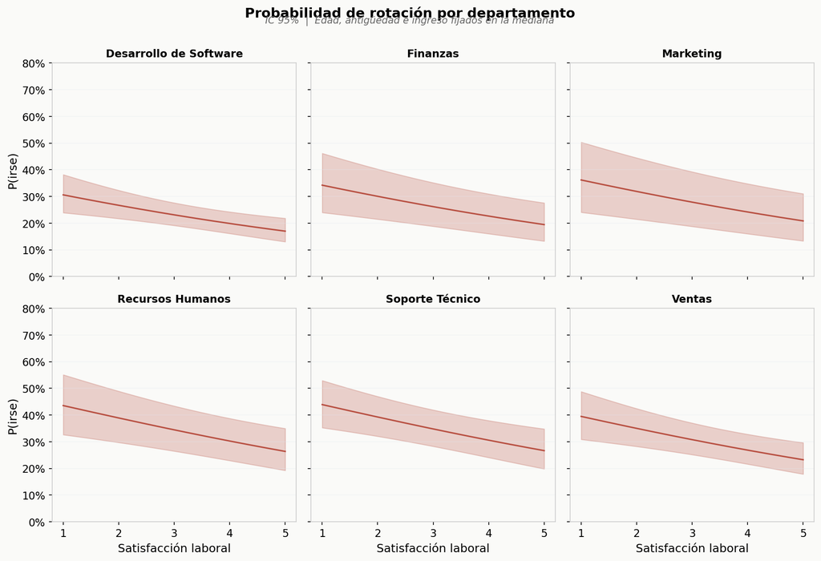

Figura 3: Predicción facetada por departamento con IC 95%

**⚠️ Por qué es importante transformar con plogis() y NO calcular el IC directamente en probabilidades**

Si calcularas el IC como `prob ± 1.96 × SE_prob`, podrías obtener valores fuera de [0, 1]. La transformación logit→plogis garantiza que el IC siempre esté entre 0 y 1, y además es asimétrico como corresponde a una probabilidad: más estrecho cerca de 0 y 1, más ancho cerca de 0.5.

**📝 Resumen: dos métodos para graficar predicciones con IC**

| Método | Cuándo usarlo | Código clave |
| --- | --- | --- |
| `geom_smooth(method="glm")` | Un solo predictor en el eje X. Rápido y correcto. | `geom_smooth(method = "glm", method.args = list(family = "binomial"))` |
| Manual: `predict(type="link") + plogis()` | Modelo multivariado. Control total sobre qué variables fijar. | `plogis(fit ± 1.96 × se.fit)` |

## 5. Evaluar el modelo

### 5.1 Matriz de confusión

```
# Clasificar con umbral 0.5
innovaco <- innovaco |>
  mutate(prediccion = if_else(prob_predicha >= 0.5, "Sí", "No"))

tabla_conf <- table(Predicho = innovaco$prediccion, Real = innovaco$rotacion)
tabla_conf

# Métricas
vn <- tabla_conf["No", "No"]
vp <- tabla_conf["Sí", "Sí"]
fp <- tabla_conf["Sí", "No"]
fn <- tabla_conf["No", "Sí"]

accuracy      <- (vp + vn) / sum(tabla_conf)
sensibilidad  <- vp / (vp + fn)
especificidad <- vn / (vn + fp)
```

### 5.2 Visualizar la matriz de confusión

```
# Preparar datos para el gráfico
conf_datos <- as.data.frame(tabla_conf) |>
  mutate(
    tipo = case_when(
      Predicho == "No" & Real == "No" ~ "Verdadero Negativo",
      Predicho == "Sí" & Real == "Sí" ~ "Verdadero Positivo",
      Predicho == "Sí" & Real == "No" ~ "Falso Positivo",
      Predicho == "No" & Real == "Sí" ~ "Falso Negativo"
    ),
    correcto = tipo %in% c("Verdadero Negativo", "Verdadero Positivo")
  )

ggplot(conf_datos, aes(x = Real, y = Predicho, fill = correcto)) +
  geom_tile(color = "white", linewidth = 2) +
  geom_text(aes(label = paste0(Freq, "\n", tipo)),
            size = 4, color = "white") +
  scale_fill_manual(values = c("TRUE" = "#0D9488", "FALSE" = "#B85042")) +
  labs(title = "Matriz de confusión", x = "Valor real", y = "Predicción") +
  theme_minimal() +
  theme(legend.position = "none")
```

### 5.3 Ranking de empleados en riesgo

```
# Los 20 empleados ACTUALES con mayor probabilidad de irse
riesgo <- innovaco |>
  filter(rotacion == "No") |>
  select(id_empleado, nombre, departamento, cargo,
         satisfaccion_laboral, antiguedad_anios, prob_predicha) |>
  arrange(desc(prob_predicha)) |>
  head(20)

riesgo

# Visualización: top 20 en riesgo
ggplot(riesgo, aes(x = prob_predicha,
                    y = reorder(paste(nombre, "-", cargo), prob_predicha))) +
  geom_col(fill = "#B85042") +
  geom_text(aes(label = scales::percent(prob_predicha, accuracy = 1)),
            hjust = -0.1, size = 3) +
  scale_x_continuous(labels = scales::percent, limits = c(0, 1)) +
  labs(
    title = "Top 20 empleados en riesgo de rotación",
    subtitle = "Empleados actuales con mayor probabilidad predicha",
    x = "Probabilidad de irse", y = NULL
  ) +
  theme_minimal()
```

## 6. Limitaciones honestas para el VP

| Limitación | Traducción para el VP |
| --- | --- |
| Solo captura insatisfacción gradual (path 4 del modelo unfolding) | "El modelo no puede predecir renuncias por shocks: un nuevo jefe, una oferta inesperada, un traslado familiar" |
| Correlación ≠ causalidad | "Que la satisfacción baja prediga rotación no significa que subirla la evite. Puede ser un síntoma, no la causa" |
| Datos retrospectivos | "Modelamos quiénes ya se fueron. Si la empresa cambia (reestructuración, nuevo gerente), el modelo puede quedar obsoleto" |
| Sin validación externa | "No probamos el modelo con datos que no haya visto. Podría funcionar peor con empleados nuevos" |
| Desbalance de clases | "El 73% no se va. El modelo puede sobreestimar su accuracy si no miramos la sensibilidad" |

**⚠️ Un modelo no reemplaza el juicio gerencial** El modelo es una herramienta para priorizar conversaciones, no un oráculo. Un empleado con probabilidad del 60% de irse puede tener razones que los datos no capturan. El modelo sugiere dónde mirar; el gerente decide qué hacer.

## 7. Checklist: ¿tu modelo está listo para el VP?

| ✓ | Criterio |
| --- | --- |
| ☐ | ¿Comparaste al menos 3 modelos con AIC? |
| ☐ | ¿Los predictores tienen sentido teórico (no solo estadístico)? |
| ☐ | ¿Reportaste odds ratios, no log-odds? |
| ☐ | ¿Incluiste intervalos de confianza? |
| ☐ | ¿Calculaste la sensibilidad (no solo el accuracy)? |
| ☐ | ¿Comparaste el accuracy con el baseline (73%)? |
| ☐ | ¿Incluiste al menos una visualización de la predicción? |
| ☐ | ¿Tradujiste todos los resultados a lenguaje de negocio? |
| ☐ | ¿Mencionaste las limitaciones honestas del modelo? |
| ☐ | ¿Diste recomendaciones concretas y accionables? |